# rapport

Hicham

2024-10-13

#1. Indicateurs Clés de Performance (KPI)

Les indicateurs clés de performance (KPI) suivants ont été calculés afin de comprendre les différentes dimensions de la consommation énergétique pour le code postal sélectionné. Les KPI sont des mesures quantitatives qui permettent d’évaluer l’efficacité énergétique à l’échelle locale.

#1.1 Consommation Énergétique Moyenne

Cet indicateur présente la consommation énergétique moyenne des foyers dans la zone d’étude sélectionnée. Cela permet de voir si la consommation est au-dessus ou en dessous de la moyenne nationale.

```
## Consommation énergétique moyenne : 10572.2 kWh
```

Commentaire : Une consommation moyenne élevée pourrait indiquer des inefficacités ou une forte dépendance énergétique dans la région, nécessitant des actions pour améliorer l’efficacité énergétique.

#1.2 Répartition des Types de Chauffage

[output not shown]

#1.3 Coût Total de la Consommation Énergétique

[figure not shown]

Commentaire : Cet indicateur est crucial pour évaluer l’impact économique des habitudes de consommation des foyers et pour identifier les zones où des aides pourraient être nécessaires pour réduire les charges énergétiques.

#2. Graphiques Additionnels

#2.1 Répartition Géographique des Adresses

[output not shown]

#2.2 Calcul de la Consommation Énergétique Moyenne

[output not shown]

#2.3 Calcul du Coût Moyen par Catégorie Énergétique

[output not shown]

#2.4 Calcul de la Corrélation entre la Surface Habitable et la Consommation Énergétique

```
## Corrélation entre la surface habitable et la consommation énergétique : 0.01140055
```

Commentaire : La corrélation entre la surface habitable et la consommation énergétique est importante pour comprendre si la consommation est proportionnelle à la taille du logement. Une corrélation forte indique que la surface est un facteur déterminant pour la consommation.

#2.5 Calcul de la Consommation Énergétique Moyenne par Étiquette DPE

| Etiquette_DPE | conso_moyenne |
| --- | --- |
| A | 3957.717 |
| B | 7020.153 |
| C | 10920.067 |
| D | 13447.472 |
| E | 17704.572 |
| F | 17731.357 |
| G | 45286.000 |

Commentaire : Ce tableau fournit des informations sur l’efficacité énergétique des logements en fonction de leur étiquette DPE. Il permet de comparer les consommations moyennes entre les différentes catégories, ce qui est crucial pour cibler des interventions spécifiques pour les logements les plus énergivores.

#2.6 Calcul de la Consommation Énergétique Moyenne par Catégorie de Surface Habitable

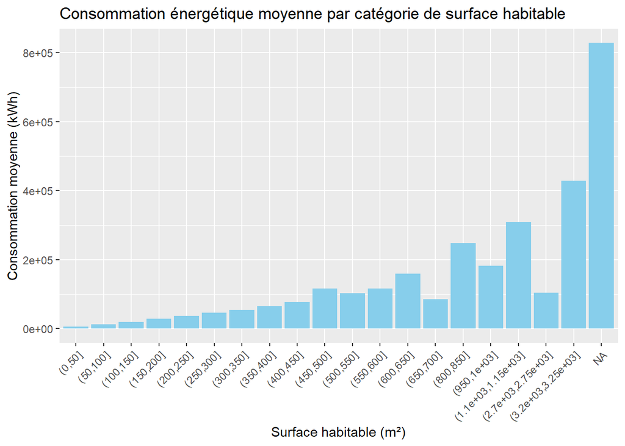